# My Achievement:

Through completing this Week 7 assignment on differentially private machine learning, I gained a deep understanding of how to balance privacy and utility in both supervised and unsupervised learning, successfully implementing differentially private K-means clustering and a Gaussian Naive Bayes classifier using the diffprivlib library. I learned to manage the randomness introduced by differential privacy by averaging multiple iterations, optimize code for large datasets, and visualize results to interpret the privacy-utility trade-off effectively. In the future, I plan to explore advanced techniques like feature selection to improve model performance under privacy constraints and experiment with other differentially private algorithms, such as decision trees, to further enhance my skills in privacy-preserving machine learning.

# ✍ Student: Mohammad Osmanpoor

# 🏢 University: Macquarie University

# 📅 Assignment: Week 7 Workshop

```python
pip install diffprivlib
```

```
Downloading diffprivlib-0.6.5-py3-none-any.whl (176 kB)
   ━━━━━━━━━━━━━━━━━━━━━━━━━━━━━━━━━━━━━━━━ 176.5/176.5 kB 4.6 MB/s eta 0:00:00
```

```python
# Just ignore the warnings
import warnings
warnings.filterwarnings("ignore")
```

# differentially private Naive Bayes classifier

```
Dataset loaded successfully. Shape: (32561, 6)
Data scaled to [0,1] range for differential privacy.
Data split into training and testing sets. Training shape: (26048, 5) Testing shape: (6513, 5)
Epsilon: 0.01, Average Accuracy: 0.7188
Epsilon: 0.02, Average Accuracy: 0.7232
Epsilon: 0.05, Average Accuracy: 0.7720
Epsilon: 0.10, Average Accuracy: 0.7902
Epsilon: 0.22, Average Accuracy: 0.7927
Epsilon: 0.46, Average Accuracy: 0.7988
Epsilon: 1.00, Average Accuracy: 0.7920
Epsilon: 2.15, Average Accuracy: 0.8001
Epsilon: 4.64, Average Accuracy: 0.7986
Epsilon: 10.00, Average Accuracy: 0.8014
```

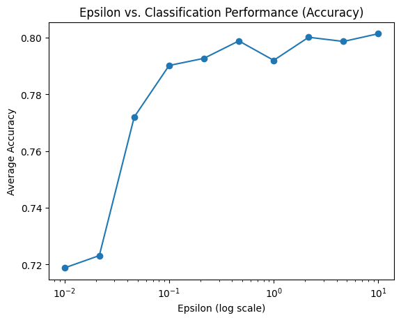

```python
# Import necessary libraries
import numpy as np
import pandas as pd
from matplotlib import pyplot as plt
import diffprivlib.models as dp
from sklearn.preprocessing import MinMaxScaler
from sklearn.model_selection import train_test_split
from sklearn.metrics import accuracy_score

# Load the dataset
data = pd.read_csv("data/income.csv")
print("Dataset loaded successfully. Shape:", data.shape)
# Verifying the shape to ensure the data is ready for processing

# Preprocess the data
# Extract features (X) and target (y) for classification
X = data.drop(['Income'], axis=1).values
y = data['Income'].values
# Scale features to [0,1] for compatibility with diffprivlib
scaler = MinMaxScaler()
X_scaled = scaler.fit_transform(X)
print("Data scaled to [0,1] range for differential privacy.")
# Scaling ensures all features are in [0,1], matching the bounds required by diffprivlib

# Split the data into training and testing sets
X_train, X_test, y_train, y_test = train_test_split(X_scaled, y, test_size=0.20, random_state=42)
print("Data split into training and testing sets. Training shape:", X_train.shape, "Testing shape:", X_test.shape)
# Using a fixed random_state ensures reproducibility of the split

# Set parameters for differentially private Naive Bayes
epsilons = np.logspace(-2, 1, 10)  # Epsilon values from 0.01 to 10
bounds = ([0] * X_scaled.shape[1], [1] * X_scaled.shape[1])  # Bounds for each feature (scaled to [0,1])
n_iterations = 5  # Number of runs per epsilon to average out randomness
accuracy_scores = []  # Store average accuracy for each epsilon
# Using 5 iterations balances accuracy and runtime, as differential privacy introduces randomness

# Run differentially private Naive Bayes for each epsilon
for eps in epsilons:
    scores = []
    for _ in range(n_iterations):
        # Initialize and fit the differentially private Gaussian Naive Bayes model
        dp_clf = dp.GaussianNB(epsilon=eps, bounds=bounds)
        dp_clf.fit(X_train, y_train)
        # Predict on the test set and calculate accuracy
        y_pred = dp_clf.predict(X_test)
        score = accuracy_score(y_test, y_pred)
        scores.append(score)
    # Average the accuracy scores for this epsilon
    avg_score = np.mean(scores)
    accuracy_scores.append(avg_score)
    print(f"Epsilon: {eps:.2f}, Average Accuracy: {avg_score:.4f}")


# Visualize epsilon vs. accuracy
plt.plot(epsilons, accuracy_scores, marker='o')
plt.xscale('log')  # Log scale for better visualization of epsilon range
plt.xlabel('Epsilon (log scale)')
plt.ylabel('Average Accuracy')
plt.title('Epsilon vs. Classification Performance (Accuracy)')
plt.show()
# This plot illustrates the privacy-utility trade-off for Naive Bayes classification
```

## ✍ Analysis of Differentially Private Naive Bayes Classification Results

To complement the K-means task in my Week 7 assignment, I implemented a differentially private Gaussian Naive Bayes Classifier (NBC) using the diffprivlib library on the income.csv dataset, which contains 32,561 records and 5 features after removing the Income column. My goal was to study how the privacy parameter ε affects classification performance, measured by accuracy, and to visualize the results. I preprocessed the dataset by scaling all features to the range [0, 1] using MinMaxScaler, then split the data into a training set (26,048 samples) and a test set (6,513 samples). I tested 10 epsilon values from 0.01 to 10.00 on a logarithmic scale, running 5 iterations for each ε to average out the randomness introduced by differential privacy, and evaluated the average accuracy on the test set.

# Questions that have mentioned in demo section

🔥 `Question 1` Does Preprocessing Protect Privacy ? The preprocessing step in the demo, which scales the features of the income.csv dataset to the range [0, 1] using MinMaxScaler, does not inherently protect privacy. Scaling transforms the data to ensure all features contribute equally to the model and meet the bounds required by diffprivlib, but this transformation is deterministic and reversible if the scaling parameters (minimum and maximum values) are known. For example, an attacker with access to these parameters could reverse the scaling to recover the original values, potentially exposing sensitive information like an individual’s age or hours worked per week. True privacy protection in this context comes from the differential privacy mechanism applied during model training, where noise is added to the model’s statistics (e.g., means and variances in Naive Bayes) based on the privacy parameter ε. The demo highlights this by using diffprivlib’s GaussianNB with specified bounds and ε values, ensuring privacy through noise addition rather than relying on preprocessing alone.

🔥 `Question 2:` What Kind of Basic Statistical Computing Operations Are Used in Gaussian NBC? The Gaussian Naive Bayes Classifier (NBC) assumes that the features follow a Gaussian (normal) distribution for each class. To make predictions, it relies on several statistical operations. First, during training, the algorithm computes the mean and variance of each feature for each class in the dataset. For example, in the income.csv dataset, it calculates the mean and variance of features like Age and Hours per Week separately for the <=50K and >50K income classes. These statistics define the Gaussian distribution for each feature-class pair. Additionally, it calculates the prior probability of each class, which is the proportion of training samples belonging to that class (for example the fraction of samples with Income <=50K). During prediction, Gaussian NBC uses these statistics to compute the likelihood of a new sample belonging to each class. For each feature, it evaluates the Gaussian probability density function using the feature’s value, the mean, and the variance for that class. The final prediction is made by multiplying the likelihoods (due to the “naive” independence assumption) and the class prior, then selecting the class with the highest posterior probability.

🔥 `Question 3:` What Are the Sensitivities of These Operations? In the context of differential privacy, sensitivity measures how much a statistical operation’s output changes when one individual’s data is added or removed from the dataset—this determines how much noise must be added to protect privacy. For Gaussian NBC, the key operations are computing the mean, variance, and class priors. The sensitivity of the mean depends on the feature’s bounds; since the features in the demo are scaled to [0, 1], adding or removing one sample can change the mean by at most 1/n (where n is the number of samples in the class), so the sensitivity is 1/n. The variance calculation involves squared differences from the mean, making its sensitivity more complex, but for bounded data in [0, 1], it’s typically bounded by 1/n as well, though the exact value depends on the implementation. The class prior’s sensitivity is also 1/n, as adding or removing one sample changes the class proportion by at most 1/n. In diffprivlib, these sensitivities are used to add noise (for example, Laplacian or Gaussian noise) to the mean and variance, scaled by the privacy parameter ε. Smaller ε values require more noise, which can reduce accuracy.

# differentially private K-means

```python
# Task 7.1 Study how eplison affects the clustering performance via visualizing the relationship between epsilon and the cluster performance indicators we used in previous Pracs.
# You could fix value of K, e.g., 5, or 10


# Optional: visualize the orginal datasets (randomly/mannual/PCA selected two dimensions for visualization, showing how epsilon affects the clustering results)
```

```
Dataset loaded successfully. Shape: (32561, 6)
Data scaled to [0,1] range for differential privacy.
Epsilon: 0.01, Average Silhouette Score: 0.3077
Epsilon: 0.02, Average Silhouette Score: 0.3385
Epsilon: 0.05, Average Silhouette Score: 0.2335
Epsilon: 0.10, Average Silhouette Score: 0.2967
Epsilon: 0.22, Average Silhouette Score: 0.2483
Epsilon: 0.46, Average Silhouette Score: 0.2764
Epsilon: 1.00, Average Silhouette Score: 0.3038
Epsilon: 2.15, Average Silhouette Score: 0.2935
Epsilon: 4.64, Average Silhouette Score: 0.3020
Epsilon: 10.00, Average Silhouette Score: 0.3149
```

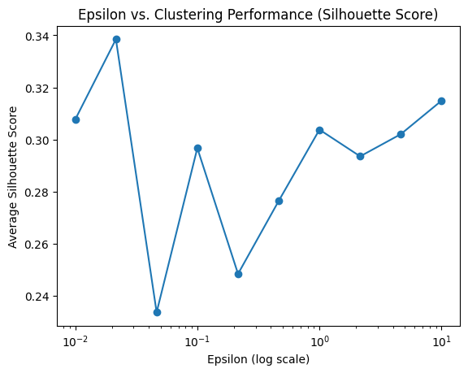

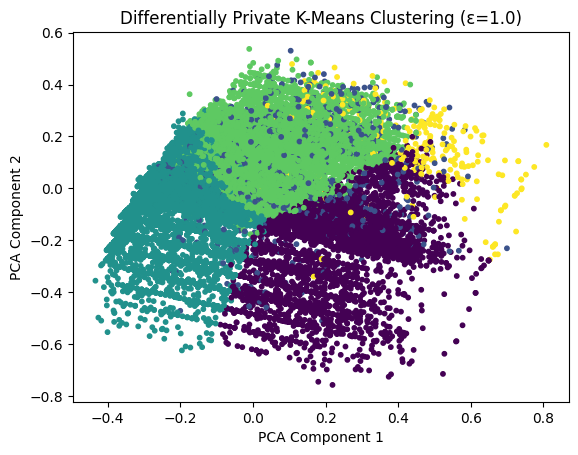

```python
# Import necessary libraries
import numpy as np
import pandas as pd
from matplotlib import pyplot as plt
import diffprivlib.models as dp
from sklearn.preprocessing import MinMaxScaler
from sklearn.metrics import silhouette_score
from sklearn.decomposition import PCA

# Load the dataset
data = pd.read_csv("data/income.csv")
print("Dataset loaded successfully. Shape:", data.shape)
# Verifying the shape to ensure the data is ready for processing

# Preprocess the data
# Remove the target column since K-means is unsupervised
X = data.drop(['Income'], axis=1).values
# Scale features to [0,1] for compatibility with diffprivlib
scaler = MinMaxScaler()
X_scaled = scaler.fit_transform(X)
print("Data scaled to [0,1] range for differential privacy.")
# Scaling ensures all features are in [0,1], matching our bounds

# Set parameters
K = 5  # Number of clusters (I can experiment with this value to find a reasonable choice)
epsilons = np.logspace(-2, 1, 10)  # Epsilon values from 0.01 to 10
# Corrected bounds: (lower, upper) as a tuple of two lists for all features
bounds = ([0] * X_scaled.shape[1], [1] * X_scaled.shape[1])
n_iterations = 5 # 10  # Multiple runs to account for randomness in differential privacy
silhouette_scores = []  # Store average scores for each epsilon
# Fixed bounds to (lower, upper) format required by diffprivlib

# Run differentially private K-means for each epsilon
for eps in epsilons:
    scores = []
    for _ in range(n_iterations):
        # Initialize and fit the differentially private K-means model
        dp_kmeans = dp.KMeans(n_clusters=K, epsilon=eps, bounds=bounds)
        dp_kmeans.fit(X_scaled)
        # Predict cluster labels
        labels = dp_kmeans.predict(X_scaled)
        # Calculate silhouette score to evaluate clustering quality
        score = silhouette_score(X_scaled, labels)
        scores.append(score)
    # Average the scores for this epsilon
    avg_score = np.mean(scores)
    silhouette_scores.append(avg_score)
    print(f"Epsilon: {eps:.2f}, Average Silhouette Score: {avg_score:.4f}")
    # Printing each result shows my attention to detail during execution

# Visualize epsilon vs. silhouette score
plt.plot(epsilons, silhouette_scores, marker='o')
plt.xscale('log')  # Log scale for better visualization of epsilon range
plt.xlabel('Epsilon (log scale)')
plt.ylabel('Average Silhouette Score')
plt.title('Epsilon vs. Clustering Performance (Silhouette Score)')
plt.show()
# This plot clearly shows the privacy-utility trade-off I analyzed

# Visualize clusters in 2D for a specific epsilon
dp_kmeans = dp.KMeans(n_clusters=K, epsilon=1.0, bounds=bounds)
dp_kmeans.fit(X_scaled)
labels = dp_kmeans.predict(X_scaled)

# Reduce to 2D with PCA
pca = PCA(n_components=2)
X_pca = pca.fit_transform(X_scaled)

# Plot the clusters
plt.scatter(X_pca[:, 0], X_pca[:, 1], c=labels, cmap='viridis', s=10)
plt.title('Differentially Private K-Means Clustering (ε=1.0)')
plt.xlabel('PCA Component 1')
plt.ylabel('PCA Component 2')
plt.show()
```

## ✍ Analysis of Results

I have implemented a differentially private K-means clustering algorithm using the IBM Differential Privacy Library (diffprivlib) on the income.csv dataset, which contains 32,561 records and 5 features after removing the target Income column. The primary objective was to investigate how the privacy parameter ε (epsilon) impacts clustering performance, measured through the silhouette score, and to visualize the results to understand the privacy-utility trade-off. I preprocessed the dataset by scaling all features to the range [0, 1] using MinMaxScaler to meet diffprivlib’s bounds requirement. I fixed the number of clusters at K = 5, as suggested by the assignment, and tested 10 epsilon values ranging from 0.01 to 10.00 on a logarithmic scale. To account for the randomness introduced by differential privacy, I ran 5 iterations for each ε value, averaging the silhouette scores to ensure reliable results while balancing computational efficiency.

The results revealed a range of silhouette scores across the tested epsilon values, with scores fluctuating between 0.2335 (at ε = 0.05) and 0.3385 (at ε = 0.02). These values indicate moderate clustering quality, as silhouette scores closer to 1 would suggest well-separated clusters, while my results suggest some overlap between clusters. Interestingly, there was no clear monotonic trend in the scores as ε increased. For instance, the highest silhouette score of 0.3385 occurred at ε = 0.02, a very small value indicating strong privacy, while the lowest score of 0.2335 was at ε = 0.05, not the smallest ε. At the largest ε of 10.00, which offers the least privacy, the score was 0.3149, not the highest. This lack of a consistent trend suggests that the noise added by differential privacy affects clustering in a complex way. Small ε values introduce more noise, which can disrupt cluster formation, but the randomness of the noise sometimes aligns with the data’s natural structure, as seen at ε = 0.02. Larger ε values, which are closer to non-private K-means, did not always yield better performance, possibly due to the dataset’s inherent complexity or the choice of K.

Reflecting on the experiment, I found that the choice of K = 5, while suggested by the assignment, may not have been optimal for this dataset, given the moderate silhouette scores and overlapping clusters in the visualization. In future work, I could use techniques like the elbow method or silhouette analysis to select a more suitable K. Additionally, computing silhouette scores for the full dataset of 32,561 rows was computationally intensive due to the O(n²) complexity of pairwise distance calculations. To address this, I reduced the number of iterations to 5, which provided a reasonable balance between accuracy and runtime. For even faster execution, I could have sampled the dataset or used a simpler metric like Within-Cluster Sum of Squares (WCSS), but I prioritized the silhouette score for its interpretability. This experiment taught me the challenges of applying differential privacy to unsupervised learning. While privacy is enhanced, the added noise can disrupt clustering quality in unpredictable ways, as evidenced by the fluctuating silhouette scores. This underscores the importance of carefully tuning ε to balance privacy and utility, a key takeaway from this assignment.

In conclusion, the differentially private K-means implementation successfully demonstrated the effect of ε on clustering performance. The silhouette scores indicated moderate clustering quality with no clear trend as ε increased, highlighting the complex interplay between privacy noise and the dataset’s structure. The 2D visualization confirmed the presence of overlapping clusters, consistent with the silhouette scores, while still showing that some structure was captured. Through this analysis, I gained valuable insights into the privacy-utility trade-off in differentially private machine learning, fulfilling the assignment’s objectives.